# Portfolio assignment 11

Do a Numerical VS Categorical bivariate analysis on the penguins dataset.

- Choose one of the categorical columns: species, island or sex
- use .groupby('').mean() too look at the means of the numerical columns. Does it look like there is a difference between categories?
- Use the seaborn barplot to plot the mean and confidence. Create this plot for each of the numerical columns (bill_length_mm bill_depth_mm, flipper_length_mm, body_mass_g)
- For each of the plots, write a conclusion: Is there a statistically significant difference for this numerical column for each category?
- Optional: Repeat this proces for the other two categorical columns

```python
import pandas as pd
pd.options.mode.chained_assignment = None

import seaborn as sns
```

```python
data = sns.load_dataset('penguins')
data.shape
```

```
(344, 7)
```

### Analysis on the difference between the species

```python
data.groupby('species').mean()
```

| species | bill_length_mm | bill_depth_mm | flipper_length_mm | body_mass_g |
| --- | --- | --- | --- | --- |
| Adelie | 38.791391 | 18.346358 | 189.953642 | 3700.662252 |
| Chinstrap | 48.833824 | 18.420588 | 195.823529 | 3733.088235 |
| Gentoo | 47.504878 | 14.982114 | 217.186992 | 5076.016260 |

There are a some interesting things in the chart above.

- Adelie penguins have the shortest bill length. They also are the lighest from those three species, so we can conclude they are the smallest penguins
- The flipper length differs per species, with Gentoo penguins having the longest flippers
- The Gentoo is by far the heaviest species.

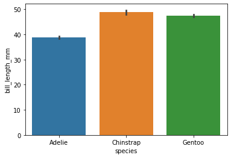

```python
sns.barplot(ci=95, x='species', y='bill_length_mm', data=data)
```

Adelie clearly has the shortest bill length. Chinstrap and Gentoo are quite close together, we can't tell them apart from this data.

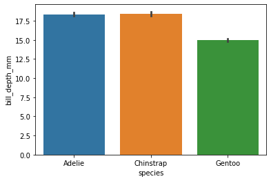

```python
sns.barplot(ci=95, x='species', y='bill_depth_mm', data=data)
```

Adelie and Chinstrap have praktically the same bill depth. But Gentoo has by far the shortest.

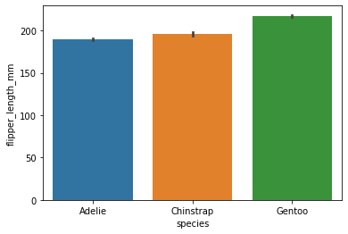

```python
sns.barplot(ci=95, x='species', y='flipper_length_mm', data=data)
```

The Gentoo penguins' flippers are about 2 cm longer compared to Chinstrap, this difference is much more clear.

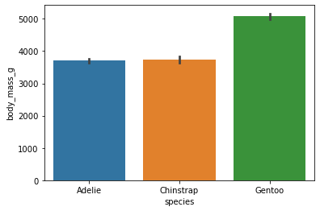

```python
sns.barplot(ci=95, x='species', y='body_mass_g', data=data)
```

There is no weight difference between Adelie and Chinstrap. But Gentoo is much heavier.